# Netflix

**About NETFLIX**

Netflix is one of the most popular media and video streaming platforms. They have over 10000 movies or tv shows available on their platform, as of mid-2021, they have over 222M Subscribers globally. This tabular dataset consists of listings of all the movies and tv shows available on Netflix, along with details such as - cast, directors, ratings, release year, duration, etc.

**Business Problem**

Analyze the data and generate insights that could help Netflix in deciding which type of shows/movies to produce and how they can grow the business in different countries

```python
from google.colab import files
uploaded = files.upload()
```

Upload widget is only available when the cell has been executed in the current browser session. Please rerun this cell to enable.

```
Saving d2beiqkhq929f0.cloudfront.net_public_assets_assets_000_000_940_original_netflix.csv to d2beiqkhq929f0.cloudfront.net_public_assets_assets_000_000_940_original_netflix.csv
```

```python
import numpy as np
```

```python
import pandas as pd
```

```python
import matplotlib.pyplot as plt
```

```python
import seaborn as sns
```

```python
from wordcloud import WordCloud
```

```python
df = pd.read_csv('d2beiqkhq929f0.cloudfront.net_public_assets_assets_000_000_940_original_netflix.csv')
df.head()
```

|  | show_id | type | title | director | cast | country | date_added | release_year | rating | duration | listed_in | description |
| --- | --- | --- | --- | --- | --- | --- | --- | --- | --- | --- | --- | --- |
| 0 | s1 | Movie | Dick Johnson Is Dead | Kirsten Johnson | NaN | United States | September 25, 2021 | 2020 | PG-13 | 90 min | Documentaries | As her father nears the end of his life, filmm... |
| 1 | s2 | TV Show | Blood & Water | NaN | Ama Qamata, Khosi Ngema, Gail Mabalane, Thaban... | South Africa | September 24, 2021 | 2021 | TV-MA | 2 Seasons | International TV Shows, TV Dramas, TV Mysteries | After crossing paths at a party, a Cape Town t... |
| 2 | s3 | TV Show | Ganglands | Julien Leclercq | Sami Bouajila, Tracy Gotoas, Samuel Jouy, Nabi... | NaN | September 24, 2021 | 2021 | TV-MA | 1 Season | Crime TV Shows, International TV Shows, TV Act... | To protect his family from a powerful drug lor... |
| 3 | s4 | TV Show | Jailbirds New Orleans | NaN | NaN | NaN | September 24, 2021 | 2021 | TV-MA | 1 Season | Docuseries, Reality TV | Feuds, flirtations and toilet talk go down amo... |
| 4 | s5 | TV Show | Kota Factory | NaN | Mayur More, Jitendra Kumar, Ranjan Raj, Alam K... | India | September 24, 2021 | 2021 | TV-MA | 2 Seasons | International TV Shows, Romantic TV Shows, TV ... | In a city of coaching centers known to train I... |

```python
df.nunique()
```

```
show_id         8807
type               2
title           8807
director        4528
cast            7692
country          748
date_added      1767
release_year      74
rating            17
duration         220
listed_in        514
description     8775
dtype: int64
```

Check type of data

```python
type(df)
```

```
pandas.core.frame.DataFrame
```

Columns in dataframe

```python
df.columns
```

```
Index(['show_id', 'type', 'title', 'director', 'cast', 'country', 'date_added',
       'release_year', 'rating', 'duration', 'listed_in', 'description'],
      dtype='object')
```

Shape of data

```python
df.shape
```

```
(8807, 12)
```

Statistical details of dataset.

```python
df.describe()
```

|  | release_year |
| --- | --- |
| count | 8807.000000 |
| mean | 2014.180198 |
| std | 8.819312 |
| min | 1925.000000 |
| 25% | 2013.000000 |
| 50% | 2017.000000 |
| 75% | 2019.000000 |
| max | 2021.000000 |

Check data type of each column

```python
df.dtypes
```

```
show_id         object
type            object
title           object
director        object
cast            object
country         object
date_added      object
release_year     int64
rating          object
duration        object
listed_in       object
description     object
dtype: object
```

Count of null values in each column

```python
df.isnull().sum()
```

```
show_id            0
type               0
title              0
director        2634
cast             825
country          831
date_added        10
release_year       0
rating             4
duration           3
listed_in          0
description        0
dtype: int64
```

Converting Nested columns to unnested for better analysis.

```python
df.head(5) #This is nested data which we have to unnest for better analysis
```

|  | show_id | type | title | director | cast | country | date_added | release_year | rating | duration | listed_in | description |
| --- | --- | --- | --- | --- | --- | --- | --- | --- | --- | --- | --- | --- |
| 0 | s1 | Movie | Dick Johnson Is Dead | Kirsten Johnson | NaN | United States | September 25, 2021 | 2020 | PG-13 | 90 min | Documentaries | As her father nears the end of his life, filmm... |
| 1 | s2 | TV Show | Blood & Water | NaN | Ama Qamata, Khosi Ngema, Gail Mabalane, Thaban... | South Africa | September 24, 2021 | 2021 | TV-MA | 2 Seasons | International TV Shows, TV Dramas, TV Mysteries | After crossing paths at a party, a Cape Town t... |
| 2 | s3 | TV Show | Ganglands | Julien Leclercq | Sami Bouajila, Tracy Gotoas, Samuel Jouy, Nabi... | NaN | September 24, 2021 | 2021 | TV-MA | 1 Season | Crime TV Shows, International TV Shows, TV Act... | To protect his family from a powerful drug lor... |
| 3 | s4 | TV Show | Jailbirds New Orleans | NaN | NaN | NaN | September 24, 2021 | 2021 | TV-MA | 1 Season | Docuseries, Reality TV | Feuds, flirtations and toilet talk go down amo... |
| 4 | s5 | TV Show | Kota Factory | NaN | Mayur More, Jitendra Kumar, Ranjan Raj, Alam K... | India | September 24, 2021 | 2021 | TV-MA | 2 Seasons | International TV Shows, Romantic TV Shows, TV ... | In a city of coaching centers known to train I... |

```python
func1= df['cast'].apply(lambda x: str(x).split(',')).tolist()

df1 = pd.DataFrame(func1, index = df['title'])
df1 = df1.stack()
df1 = pd.DataFrame(df1)
df1.reset_index(inplace=True)
df1=df1[['title',0]]
df1.columns=['title','cast']
df1
```

|  | title | cast |
| --- | --- | --- |
| 0 | Dick Johnson Is Dead | nan |
| 1 | Blood & Water | Ama Qamata |
| 2 | Blood & Water | Khosi Ngema |
| 3 | Blood & Water | Gail Mabalane |
| 4 | Blood & Water | Thabang Molaba |
| ... | ... | ... |
| 64946 | Zubaan | Manish Chaudhary |
| 64947 | Zubaan | Meghna Malik |
| 64948 | Zubaan | Malkeet Rauni |
| 64949 | Zubaan | Anita Shabdish |
| 64950 | Zubaan | Chittaranjan Tripathy |

64951 rows × 2 columns

```python
func2= df['director'].apply(lambda x: str(x).split(',')).tolist()

df2 = pd.DataFrame(func2, index = df['title'])
df2 = df2.stack()
df2 = pd.DataFrame(df2)
df2.reset_index(inplace=True)
df2=df2[['title',0]]
df2.columns=['title','director']
df2
```

|  | title | director |
| --- | --- | --- |
| 0 | Dick Johnson Is Dead | Kirsten Johnson |
| 1 | Blood & Water | nan |
| 2 | Ganglands | Julien Leclercq |
| 3 | Jailbirds New Orleans | nan |
| 4 | Kota Factory | nan |
| ... | ... | ... |
| 9607 | Zodiac | David Fincher |
| 9608 | Zombie Dumb | nan |
| 9609 | Zombieland | Ruben Fleischer |
| 9610 | Zoom | Peter Hewitt |
| 9611 | Zubaan | Mozez Singh |

9612 rows × 2 columns

```python
func3= df['country'].apply(lambda x: str(x).split(',')).tolist()

df3 = pd.DataFrame(func3, index = df['title'])
df3 = df3.stack()
df3 = pd.DataFrame(df3)
df3.reset_index(inplace=True)
df3=df3[['title',0]]
df3.columns=['title','country']
df3
```

|  | title | country |
| --- | --- | --- |
| 0 | Dick Johnson Is Dead | United States |
| 1 | Blood & Water | South Africa |
| 2 | Ganglands | nan |
| 3 | Jailbirds New Orleans | nan |
| 4 | Kota Factory | India |
| ... | ... | ... |
| 10845 | Zodiac | United States |
| 10846 | Zombie Dumb | nan |
| 10847 | Zombieland | United States |
| 10848 | Zoom | United States |
| 10849 | Zubaan | India |

10850 rows × 2 columns

```python
func4= df['listed_in'].apply(lambda x: str(x).split(',')).tolist()

df4 = pd.DataFrame(func4, index = df['title'])
df4 = df4.stack()
df4 = pd.DataFrame(df4)
df4.reset_index(inplace=True)
df4=df4[['title',0]]
df4.columns=['title','listed_in']
df4
```

|  | title | listed_in |
| --- | --- | --- |
| 0 | Dick Johnson Is Dead | Documentaries |
| 1 | Blood & Water | International TV Shows |
| 2 | Blood & Water | TV Dramas |
| 3 | Blood & Water | TV Mysteries |
| 4 | Ganglands | Crime TV Shows |
| ... | ... | ... |
| 19318 | Zoom | Children & Family Movies |
| 19319 | Zoom | Comedies |
| 19320 | Zubaan | Dramas |
| 19321 | Zubaan | International Movies |
| 19322 | Zubaan | Music & Musicals |

19323 rows × 2 columns

```python
df5 = df[['title', "show_id", "type", "date_added","release_year","rating", "duration", "description"]]
df5
```

|  | title | show_id | type | date_added | release_year | rating | duration | description |
| --- | --- | --- | --- | --- | --- | --- | --- | --- |
| 0 | Dick Johnson Is Dead | s1 | Movie | September 25, 2021 | 2020 | PG-13 | 90 min | As her father nears the end of his life, filmm... |
| 1 | Blood & Water | s2 | TV Show | September 24, 2021 | 2021 | TV-MA | 2 Seasons | After crossing paths at a party, a Cape Town t... |
| 2 | Ganglands | s3 | TV Show | September 24, 2021 | 2021 | TV-MA | 1 Season | To protect his family from a powerful drug lor... |
| 3 | Jailbirds New Orleans | s4 | TV Show | September 24, 2021 | 2021 | TV-MA | 1 Season | Feuds, flirtations and toilet talk go down amo... |
| 4 | Kota Factory | s5 | TV Show | September 24, 2021 | 2021 | TV-MA | 2 Seasons | In a city of coaching centers known to train I... |
| ... | ... | ... | ... | ... | ... | ... | ... | ... |
| 8802 | Zodiac | s8803 | Movie | November 20, 2019 | 2007 | R | 158 min | A political cartoonist, a crime reporter and a... |
| 8803 | Zombie Dumb | s8804 | TV Show | July 1, 2019 | 2018 | TV-Y7 | 2 Seasons | While living alone in a spooky town, a young g... |
| 8804 | Zombieland | s8805 | Movie | November 1, 2019 | 2009 | R | 88 min | Looking to survive in a world taken over by zo... |
| 8805 | Zoom | s8806 | Movie | January 11, 2020 | 2006 | PG | 88 min | Dragged from civilian life, a former superhero... |
| 8806 | Zubaan | s8807 | Movie | March 2, 2019 | 2015 | TV-14 | 111 min | A scrappy but poor boy worms his way into a ty... |

8807 rows × 8 columns

Unnested data

```python
df6=df1.merge(df2, on ='title', how = 'inner').merge(df3, on ='title', how= 'inner').merge(df4, on ='title', how = 'inner').merge(df5, on = 'title', how = 'inner')
df6
```

|  | title | cast | director | country | listed_in | show_id | type | date_added | release_year | rating | duration | description |
| --- | --- | --- | --- | --- | --- | --- | --- | --- | --- | --- | --- | --- |
| 0 | Dick Johnson Is Dead | nan | Kirsten Johnson | United States | Documentaries | s1 | Movie | September 25, 2021 | 2020 | PG-13 | 90 min | As her father nears the end of his life, filmm... |
| 1 | Blood & Water | Ama Qamata | nan | South Africa | International TV Shows | s2 | TV Show | September 24, 2021 | 2021 | TV-MA | 2 Seasons | After crossing paths at a party, a Cape Town t... |
| 2 | Blood & Water | Ama Qamata | nan | South Africa | TV Dramas | s2 | TV Show | September 24, 2021 | 2021 | TV-MA | 2 Seasons | After crossing paths at a party, a Cape Town t... |
| 3 | Blood & Water | Ama Qamata | nan | South Africa | TV Mysteries | s2 | TV Show | September 24, 2021 | 2021 | TV-MA | 2 Seasons | After crossing paths at a party, a Cape Town t... |
| 4 | Blood & Water | Khosi Ngema | nan | South Africa | International TV Shows | s2 | TV Show | September 24, 2021 | 2021 | TV-MA | 2 Seasons | After crossing paths at a party, a Cape Town t... |
| ... | ... | ... | ... | ... | ... | ... | ... | ... | ... | ... | ... | ... |
| 202060 | Zubaan | Anita Shabdish | Mozez Singh | India | International Movies | s8807 | Movie | March 2, 2019 | 2015 | TV-14 | 111 min | A scrappy but poor boy worms his way into a ty... |
| 202061 | Zubaan | Anita Shabdish | Mozez Singh | India | Music & Musicals | s8807 | Movie | March 2, 2019 | 2015 | TV-14 | 111 min | A scrappy but poor boy worms his way into a ty... |
| 202062 | Zubaan | Chittaranjan Tripathy | Mozez Singh | India | Dramas | s8807 | Movie | March 2, 2019 | 2015 | TV-14 | 111 min | A scrappy but poor boy worms his way into a ty... |
| 202063 | Zubaan | Chittaranjan Tripathy | Mozez Singh | India | International Movies | s8807 | Movie | March 2, 2019 | 2015 | TV-14 | 111 min | A scrappy but poor boy worms his way into a ty... |
| 202064 | Zubaan | Chittaranjan Tripathy | Mozez Singh | India | Music & Musicals | s8807 | Movie | March 2, 2019 | 2015 | TV-14 | 111 min | A scrappy but poor boy worms his way into a ty... |

202065 rows × 12 columns

Shape of unnested dataframe

```python
df6.shape
```

```
(202065, 12)
```

Check null values of unnested data

```python
df6.isnull().sum()
```

```
title             0
cast              0
director          0
country           0
listed_in         0
show_id           0
type              0
date_added      158
release_year      0
rating           67
duration          3
description       0
dtype: int64
```

Fixing the null values.

```python
df6['date_added']= df6['date_added'].fillna(0)
df6['rating'] = df6['rating'].fillna('unknown')
df6['duration'] = df6['duration'].fillna(0)
df6['cast'] = df6['cast'].fillna(0)
```

```python
df6.isnull().sum()
```

```
title           0
cast            0
director        0
country         0
listed_in       0
show_id         0
type            0
date_added      0
release_year    0
rating          0
duration        0
description     0
dtype: int64
```

Conversion of date_added column to its right datatype

```python
df6['date_added']=pd.to_datetime(df6['date_added'])
```

```python
df6.info() #INFO OF UNNESTED DATAFRAME
```

```
<class 'pandas.core.frame.DataFrame'>
Int64Index: 202065 entries, 0 to 202064
Data columns (total 12 columns):
 #   Column        Non-Null Count   Dtype
---  ------        --------------   -----
 0   title         202065 non-null  object
 1   cast          202065 non-null  object
 2   director      202065 non-null  object
 3   country       202065 non-null  object
 4   listed_in     202065 non-null  object
 5   show_id       202065 non-null  object
 6   type          202065 non-null  object
 7   date_added    202065 non-null  datetime64[ns]
 8   release_year  202065 non-null  int64
 9   rating        202065 non-null  object
 10  duration      202065 non-null  object
 11  description   202065 non-null  object
dtypes: datetime64[ns](1), int64(1), object(10)
memory usage: 20.0+ MB
```

Check unique values

```python
df6.nunique()
```

```
title            8807
cast            39297
director         5121
country           198
listed_in          73
show_id          8807
type                2
date_added       1715
release_year       74
rating             18
duration          221
description      8775
dtype: int64
```

Display first 10 values

```python
df6.head(10)
```

|  | title | cast | director | country | listed_in | show_id | type | date_added | release_year | rating | duration | description |
| --- | --- | --- | --- | --- | --- | --- | --- | --- | --- | --- | --- | --- |
| 0 | Dick Johnson Is Dead | nan | Kirsten Johnson | United States | Documentaries | s1 | Movie | 2021-09-25 | 2020 | PG-13 | 90 min | As her father nears the end of his life, filmm... |
| 1 | Blood & Water | Ama Qamata | nan | South Africa | International TV Shows | s2 | TV Show | 2021-09-24 | 2021 | TV-MA | 2 Seasons | After crossing paths at a party, a Cape Town t... |
| 2 | Blood & Water | Ama Qamata | nan | South Africa | TV Dramas | s2 | TV Show | 2021-09-24 | 2021 | TV-MA | 2 Seasons | After crossing paths at a party, a Cape Town t... |
| 3 | Blood & Water | Ama Qamata | nan | South Africa | TV Mysteries | s2 | TV Show | 2021-09-24 | 2021 | TV-MA | 2 Seasons | After crossing paths at a party, a Cape Town t... |
| 4 | Blood & Water | Khosi Ngema | nan | South Africa | International TV Shows | s2 | TV Show | 2021-09-24 | 2021 | TV-MA | 2 Seasons | After crossing paths at a party, a Cape Town t... |
| 5 | Blood & Water | Khosi Ngema | nan | South Africa | TV Dramas | s2 | TV Show | 2021-09-24 | 2021 | TV-MA | 2 Seasons | After crossing paths at a party, a Cape Town t... |
| 6 | Blood & Water | Khosi Ngema | nan | South Africa | TV Mysteries | s2 | TV Show | 2021-09-24 | 2021 | TV-MA | 2 Seasons | After crossing paths at a party, a Cape Town t... |
| 7 | Blood & Water | Gail Mabalane | nan | South Africa | International TV Shows | s2 | TV Show | 2021-09-24 | 2021 | TV-MA | 2 Seasons | After crossing paths at a party, a Cape Town t... |
| 8 | Blood & Water | Gail Mabalane | nan | South Africa | TV Dramas | s2 | TV Show | 2021-09-24 | 2021 | TV-MA | 2 Seasons | After crossing paths at a party, a Cape Town t... |
| 9 | Blood & Water | Gail Mabalane | nan | South Africa | TV Mysteries | s2 | TV Show | 2021-09-24 | 2021 | TV-MA | 2 Seasons | After crossing paths at a party, a Cape Town t... |

Check duplicate values

```python
df6.duplicated().sum()
```

```
7
```

```python
df6[df6.duplicated()]
```

|  | title | cast | director | country | listed_in | show_id | type | date_added | release_year | rating | duration | description |
| --- | --- | --- | --- | --- | --- | --- | --- | --- | --- | --- | --- | --- |
| 39354 | Rust Creek | Micah Hauptman | Jen McGowan | United States | Thrillers | s1632 | Movie | 2020-11-30 | 2018 | R | 108 min | A wrong turn in the woods becomes a fight for ... |
| 135656 | 300 Miles to Heaven | Adrianna Biedrzyńska | Maciej Dejczer | Denmark | Dramas | s6014 | Movie | 2019-10-01 | 1989 | TV-14 | 93 min | Hoping to help their dissident parents, two br... |
| 135657 | 300 Miles to Heaven | Adrianna Biedrzyńska | Maciej Dejczer | Denmark | International Movies | s6014 | Movie | 2019-10-01 | 1989 | TV-14 | 93 min | Hoping to help their dissident parents, two br... |
| 135658 | 300 Miles to Heaven | Adrianna Biedrzyńska | Maciej Dejczer | France | Dramas | s6014 | Movie | 2019-10-01 | 1989 | TV-14 | 93 min | Hoping to help their dissident parents, two br... |
| 135659 | 300 Miles to Heaven | Adrianna Biedrzyńska | Maciej Dejczer | France | International Movies | s6014 | Movie | 2019-10-01 | 1989 | TV-14 | 93 min | Hoping to help their dissident parents, two br... |
| 135660 | 300 Miles to Heaven | Adrianna Biedrzyńska | Maciej Dejczer | Poland | Dramas | s6014 | Movie | 2019-10-01 | 1989 | TV-14 | 93 min | Hoping to help their dissident parents, two br... |
| 135661 | 300 Miles to Heaven | Adrianna Biedrzyńska | Maciej Dejczer | Poland | International Movies | s6014 | Movie | 2019-10-01 | 1989 | TV-14 | 93 min | Hoping to help their dissident parents, two br... |

Drop Duplicates

```python
df6.drop_duplicates(inplace=True)
```

```python
df6[df6.duplicated()]
```

|  | title | cast | director | country | listed_in | show_id | type | date_added | release_year | rating | duration | description |
| --- | --- | --- | --- | --- | --- | --- | --- | --- | --- | --- | --- | --- |

Statistical summary of a dataset

```python
df6.describe()
```

|  | release_year |
| --- | --- |
| count | 202058.000000 |
| mean | 2013.449653 |
| std | 9.012781 |
| min | 1925.000000 |
| 25% | 2012.000000 |
| 50% | 2016.000000 |
| 75% | 2019.000000 |
| max | 2021.000000 |

DATA VISUALIZATION

Proportion of content by type

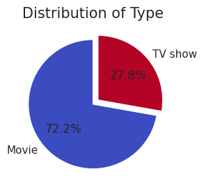

```python
plt.figure(figsize = (3,8))
labels = ['Movie', 'TV show']
size = df6['type'].value_counts()
colors = plt.cm.coolwarm(np.linspace(0, 1, 2))
explode = [0, 0.1]
plt.rcParams['figure.figsize'] = (9, 9)
plt.pie(size,labels=labels, colors = colors, explode = explode, shadow = False, autopct='%1.1f%%', startangle = 90)
plt.title('Distribution of Type', fontsize = 15)
plt.show()
plt.savefig('typedist.jpg')
```

Growth in content over the year

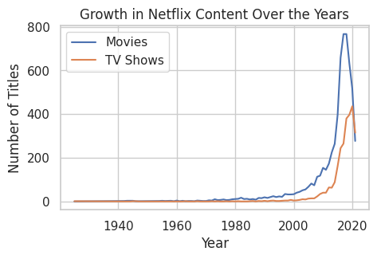

```python
content_growth = df.groupby(['release_year', 'type']).size().unstack().fillna(0)

# Plot the growth in content over the years
plt.figure(figsize=(5,3))
plt.plot(content_growth.index, content_growth['Movie'], label='Movies')
plt.plot(content_growth.index, content_growth['TV Show'], label='TV Shows')
plt.xlabel('Year')
plt.ylabel('Number of Titles')
plt.title('Growth in Netflix Content Over the Years')
plt.legend()
plt.grid(True)
plt.show()
plt.savefig('lineplot')
```

Which year released high number of TV shows and movies?

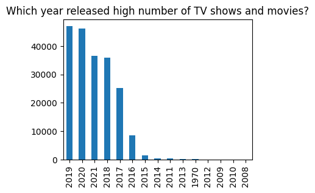

```python
plt.figure(figsize=(4,3))
df6['date_added'].dt.year.value_counts().plot(kind = 'bar')
plt.title('Which year released high number of TV shows and movies?')
```

Distribution of Netflix shows among different ratings

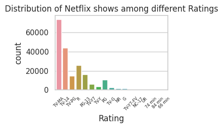

```python
plt.figure(figsize=(3,2))
sns.countplot(data = df6, x = 'rating', order=df['rating'].value_counts().index) #sns.countplot(data=df, x='rating', order=df['rating'].value_counts().index)
plt.xticks(rotation = 45, fontsize = 6)
plt.title('Distribution of Netflix shows among different Ratings')
plt.xlabel("Rating")
plt.show()
plt.savefig('rating.jpg')
```

Relation between Type and Rating

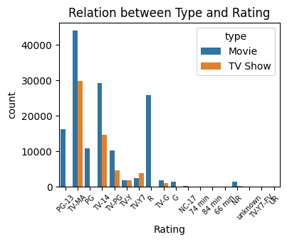

```python
plt.figure(figsize=(4,3))
sns.countplot(x='rating',hue='type',data=df6, orient = 'h')
plt.title('Relation between Type and Rating')
plt.xticks(rotation = 45, fontsize = 7)
plt.xlabel('Rating')
plt.show()
```

Show Top 10 Genres on Netflix.

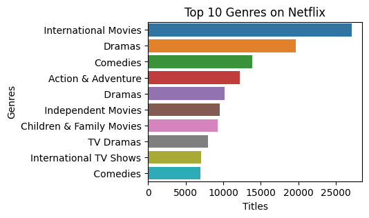

```python
filtered_genres = df6.set_index('title').listed_in.str.split(', ', expand=True).stack().reset_index(level=1, drop=True);
plt.figure(figsize=(4,3))
g = sns.countplot(y = filtered_genres, order=filtered_genres.value_counts().index[:10])
plt.title('Top 10 Genres on Netflix')
plt.xlabel('Titles')
plt.ylabel('Genres')
plt.show()
```

Show Word Cloud for Movie Genres

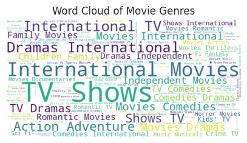

```python
all_genres = ' '.join(df['listed_in'])
wordcloud = WordCloud(width=800, height=400, background_color='white').generate(all_genres)

plt.figure(figsize=(5,3))
plt.imshow(wordcloud, interpolation='bilinear')
plt.title('Word Cloud of Movie Genres')
plt.axis('off')
plt.show()
plt.savefig('genres.jpg')
```

Popular actors in Netflix

```python
df6['cast'].value_counts().drop('nan').head(10)
```

```
 Alfred Molina        160
 Salma Hayek          130
 Frank Langella       128
 John Rhys-Davies     125
 John Krasinski       121
Liam Neeson           120
 Anupam Kher          116
David Attenborough    103
 Quvenzhané Wallis    100
 James Faulkner        93
Name: cast, dtype: int64
```

**Analysis of actors/directors of different types of shows/movies.**